# Part I - Prosper Loan Data Analysis

## Introduction

> The dataset to be investigated consist of borrower APRs and attributes of 113,937 loans. The attributes included original loan amount, borrower's Prosper rating, loan term, borrower's stated monthly income, as well as many other features such as borrower's employment status, debt to income ratio, current loan status etc. In this analysis I will look at the effects of loan properties on the Borrower APR.

## Preliminary Wrangling

```python
# import all packages and set plots to be embedded inline
import numpy as np
import pandas as pd
import matplotlib.pyplot as plt
import seaborn as sb

%matplotlib inline
```

```python
# Download file using requests library
import requests
URL = "https://s3.amazonaws.com/udacity-hosted-downloads/ud651/prosperLoanData.csv"
# 2. download the data behind the URL
response = requests.get(URL)
# 3. Open the response into a new file called instagram.ico
open("prosperLoanData.csv", "wb").write(response.content)
```

```
86471101
```

```python
loans_df = pd.read_csv('prosperLoanData.csv')
loans_df.head(5)
```

|  | ListingKey | ListingNumber | ListingCreationDate | CreditGrade | Term | LoanStatus | ClosedDate | BorrowerAPR | BorrowerRate | LenderYield | ... | LP_ServiceFees | LP_CollectionFees | LP_GrossPrincipalLoss | LP_NetPrincipalLoss | LP_NonPrincipalRecoverypayments | PercentFunded | Recommendations | InvestmentFromFriendsCount | InvestmentFromFriendsAmount | Investors |
| --- | --- | --- | --- | --- | --- | --- | --- | --- | --- | --- | --- | --- | --- | --- | --- | --- | --- | --- | --- | --- | --- |
| 0 | 1021339766868145413AB3B | 193129 | 2007-08-26 19:09:29.263000000 | C | 36 | Completed | 2009-08-14 00:00:00 | 0.16516 | 0.1580 | 0.1380 | ... | -133.18 | 0.0 | 0.0 | 0.0 | 0.0 | 1.0 | 0 | 0 | 0.0 | 258 |
| 1 | 10273602499503308B223C1 | 1209647 | 2014-02-27 08:28:07.900000000 | NaN | 36 | Current | NaN | 0.12016 | 0.0920 | 0.0820 | ... | 0.00 | 0.0 | 0.0 | 0.0 | 0.0 | 1.0 | 0 | 0 | 0.0 | 1 |
| 2 | 0EE9337825851032864889A | 81716 | 2007-01-05 15:00:47.090000000 | HR | 36 | Completed | 2009-12-17 00:00:00 | 0.28269 | 0.2750 | 0.2400 | ... | -24.20 | 0.0 | 0.0 | 0.0 | 0.0 | 1.0 | 0 | 0 | 0.0 | 41 |
| 3 | 0EF5356002482715299901A | 658116 | 2012-10-22 11:02:35.010000000 | NaN | 36 | Current | NaN | 0.12528 | 0.0974 | 0.0874 | ... | -108.01 | 0.0 | 0.0 | 0.0 | 0.0 | 1.0 | 0 | 0 | 0.0 | 158 |
| 4 | 0F023589499656230C5E3E2 | 909464 | 2013-09-14 18:38:39.097000000 | NaN | 36 | Current | NaN | 0.24614 | 0.2085 | 0.1985 | ... | -60.27 | 0.0 | 0.0 | 0.0 | 0.0 | 1.0 | 0 | 0 | 0.0 | 20 |

5 rows × 81 columns

```python
# Overview of data shape
loans_df.shape
```

```
(113937, 81)
```

```python
# Select columns of interest
df_loans = loans_df.loc[:, ['ListingCreationDate','CreditGrade' ,'Term', 'LoanStatus', 'ClosedDate', 'BorrowerAPR',
                         'BorrowerRate', 'LenderYield', 'ProsperRating (Alpha)', 'ProsperScore', 'ListingCategory (numeric)',
                         'BorrowerState', 'Occupation', 'EmploymentStatus', 'AmountDelinquent',
                         'IncomeRange', 'StatedMonthlyIncome',
                         'LoanCurrentDaysDelinquent',
                         'LoanOriginalAmount', 'LoanOriginationDate',
                         'MonthlyLoanPayment', 'LP_ServiceFees', 'Investors','IncomeVerifiable','IsBorrowerHomeowner']]
df_loans.info()
```

```
<class 'pandas.core.frame.DataFrame'>
RangeIndex: 113937 entries, 0 to 113936
Data columns (total 25 columns):
ListingCreationDate          113937 non-null object
CreditGrade                  28953 non-null object
Term                         113937 non-null int64
LoanStatus                   113937 non-null object
ClosedDate                   55089 non-null object
BorrowerAPR                  113912 non-null float64
BorrowerRate                 113937 non-null float64
LenderYield                  113937 non-null float64
ProsperRating (Alpha)        84853 non-null object
ProsperScore                 84853 non-null float64
ListingCategory (numeric)    113937 non-null int64
BorrowerState                108422 non-null object
Occupation                   110349 non-null object
EmploymentStatus             111682 non-null object
AmountDelinquent             106315 non-null float64
IncomeRange                  113937 non-null object
StatedMonthlyIncome          113937 non-null float64
LoanCurrentDaysDelinquent    113937 non-null int64
LoanOriginalAmount           113937 non-null int64
LoanOriginationDate          113937 non-null object
MonthlyLoanPayment           113937 non-null float64
LP_ServiceFees               113937 non-null float64
Investors                    113937 non-null int64
IncomeVerifiable             113937 non-null bool
IsBorrowerHomeowner          113937 non-null bool
dtypes: bool(2), float64(8), int64(5), object(10)
memory usage: 20.2+ MB
```

```python
# Check Duplicates
df_loans.duplicated().sum()
```

```
0
```

```python
# Create a category of income
income_cat = {'ProsperRating (Alpha)': ['N/A','HR','E','D','C', 'B', 'A', 'AA'],
                    'IncomeRange':['$0','$1-24,999','$25,000-49,999','$50,000-74,999','$75,000-99,999','$100,000+']}
for var in income_cat:
    ordered_var = pd.api.types.CategoricalDtype(ordered = True, categories = income_cat[var])
    df_loans[var] = df_loans[var].astype(ordered_var)
```

```python
df_loans['IncomeRange'].value_counts()
```

```
$25,000-49,999    32192
$50,000-74,999    31050
$100,000+         17337
$75,000-99,999    16916
$1-24,999          7274
$0                  621
Name: IncomeRange, dtype: int64
```

```python
# Create a category of Rating
rating_cat = {'ProsperRating (Alpha)': ['N/A','HR','E','D','C', 'B', 'A', 'AA']}
for var in rating_cat:
    ordered_var = pd.api.types.CategoricalDtype(ordered = True, categories = rating_cat[var])
    df_loans[var] = df_loans[var].astype(ordered_var)
```

```python
df_loans['ProsperRating (Alpha)'].value_counts()
```

```
C      18345
B      15581
A      14551
D      14274
E       9795
HR      6935
AA      5372
N/A        0
Name: ProsperRating (Alpha), dtype: int64
```

```python
df_loans.shape
```

[output not shown]

```python
df_loans.info()
```

```
<class 'pandas.core.frame.DataFrame'>
RangeIndex: 113937 entries, 0 to 113936
Data columns (total 25 columns):
ListingCreationDate          113937 non-null object
CreditGrade                  28953 non-null object
Term                         113937 non-null int64
LoanStatus                   113937 non-null object
ClosedDate                   55089 non-null object
BorrowerAPR                  113912 non-null float64
BorrowerRate                 113937 non-null float64
LenderYield                  113937 non-null float64
ProsperRating (Alpha)        84853 non-null category
ProsperScore                 84853 non-null float64
ListingCategory (numeric)    113937 non-null int64
BorrowerState                108422 non-null object
Occupation                   110349 non-null object
EmploymentStatus             111682 non-null object
AmountDelinquent             106315 non-null float64
IncomeRange                  105390 non-null category
StatedMonthlyIncome          113937 non-null float64
LoanCurrentDaysDelinquent    113937 non-null int64
LoanOriginalAmount           113937 non-null int64
LoanOriginationDate          113937 non-null object
MonthlyLoanPayment           113937 non-null float64
LP_ServiceFees               113937 non-null float64
Investors                    113937 non-null int64
IncomeVerifiable             113937 non-null bool
IsBorrowerHomeowner          113937 non-null bool
dtypes: bool(2), category(2), float64(8), int64(5), object(8)
memory usage: 18.7+ MB
```

```python
#Drop nulls in Employment Status
df_loans = df_loans.dropna(subset=['EmploymentStatus'])
df_loans.info()
```

[output not shown]

```python
#Convert loan year column to type datetime
df_loans['LoanOriginationDate'] = pd.to_datetime(df_loans['LoanOriginationDate'])
```

### What is/are the main feature(s) of interest in your dataset?

> What factors affect a loan’s outcome status? Relationship between Credit Score, Borrower APR and Prosper Rating

## Univariate Exploration

> I will start with the most important features: Borrower APR , Prosper Score, employment and income range which will help me build an intuition of how the numeric values are distributed in the dataset.

**Question: How are Borrower APR values distributed in the dataset?**

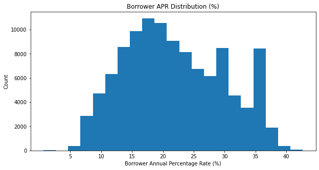

```python
binsize = 2
APR_percentage = df_loans['BorrowerAPR']*100
bins = np.arange(df_loans['BorrowerAPR'].min()*100, df_loans['BorrowerAPR'].max()*100+binsize, binsize)

plt.figure(figsize=[10, 5])
plt.hist(x = APR_percentage, bins = bins)
plt.title('Borrower APR Distribution (%)')
plt.xlabel('Borrower Annual Percentage Rate (%)')
plt.ylabel('Count')
plt.xticks([5, 10, 15, 20, 25, 30, 35, 40], ['5','10', '15', '20', '25', '30', '35', '40'])
plt.show()
```

**Question: How are Prosper Score values distributed in the dataset?**

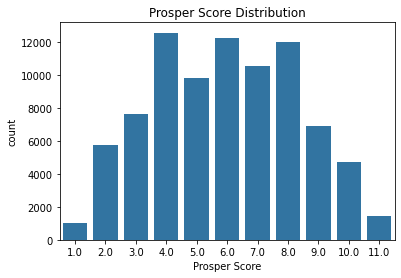

```python
base_color = sb.color_palette()[0]
sb.countplot(data=df_loans, x= 'ProsperScore', color=base_color)
plt.title('Prosper Score Distribution')
plt.xlabel('Prosper Score');
```

##### Observation

Prosper Scores are almost normally distributed and values 4, 6 and 8 are the most common.

**Question : How are the values for Employment Status ratio distributed?**

```
Text(0.5,1,'Employment Status')
```

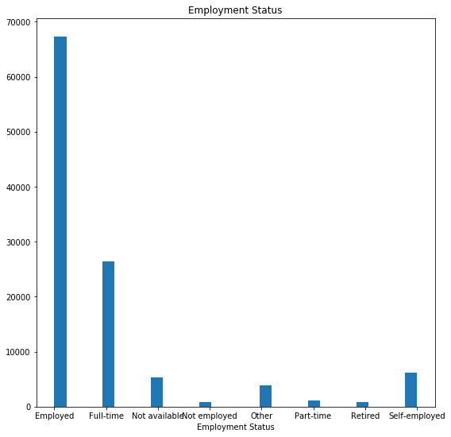

```python
base_color = sb.color_palette()[0]
plt.figure(figsize=(9, 9))

plt.hist(data=df_loans, x='EmploymentStatus', bins=30, color = base_color)
plt.xlabel('Employment Status');
plt.title('Employment Status')
```

##### Observation

The pattern in employment status shows that the majority of listings are created by employed people. It is usually difficult obtain a loan without a job.

**Question : How are the values for Income range distributed?**

```
Text(0.5,1,'Income Range Distribution')
```

[figure not shown]

```python
base_color = sb.color_palette()[0]
plt.figure(figsize=(11, 11))

plt.hist(data=df_loans, x='IncomeRange', bins=30, color = base_color)
plt.xlabel('Income range');
plt.title('Income Range Distribution')
```

##### Observation

Most of the listings pertain to borrowers earning between $25,000 and $74,999 per annum. Only a few proportion of the listings had borrowers that earned below $25,000 per annum.

**Question: How are *'IsBorrowerHomeowner', and 'IncomeVerifiable'* distributed in the dataset?**

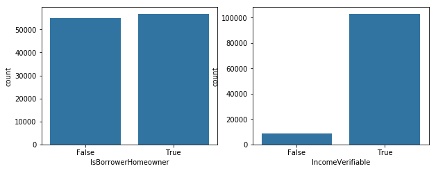

```python
fig = plt.figure(figsize=(10, 8))
# IsBorrowerHomeowner
plt.subplot(2,2,1)
sb.countplot(data=df_loans, x='IsBorrowerHomeowner', color = base_color)

# IsBorrowerHomeowner
plt.subplot(2,2,2)
sb.countplot(data=df_loans, x='IncomeVerifiable', color = base_color)
```

##### Observation

Homeowners are more commonly found requesting loans on the platform than their counterparts. The majority of borrowers on the platform have verifiable means of income. Requesting a loan without a verifiable source of income may not yeild the most desired results.

**Question: How are *'States'* distributed in the dataset?**

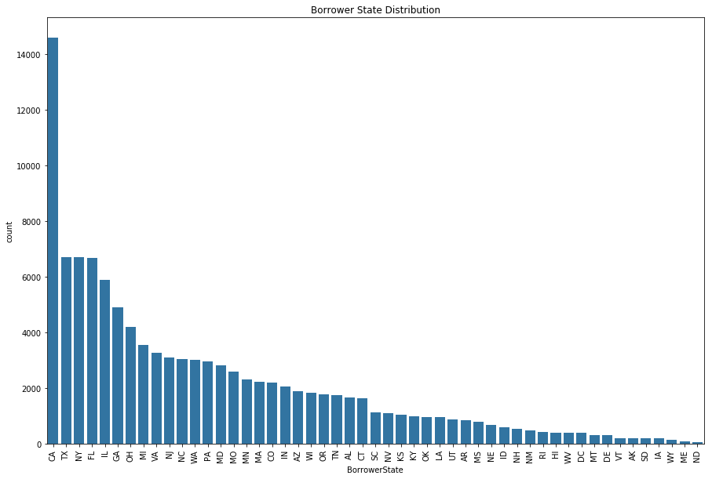

```python
cat_order = df_loans['BorrowerState'].value_counts().index
plt.figure(figsize=[15, 10])
sb.countplot(data=df_loans,x='BorrowerState',color=base_color, order=cat_order);
plt.title('Borrower State Distribution');
plt.xticks(rotation=90);
```

##### Observation

We can see that California (CA), Texas (TX) and New York (NY) have the top 3 numbers of loans that originated in the given period of time

**Question : How is the loan year distributed in the dataset?**

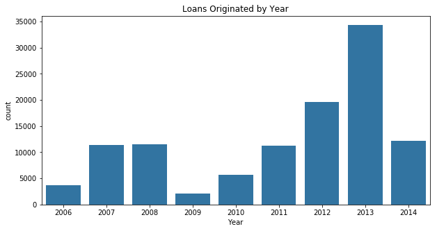

```python
plt.figure(figsize=[10, 5])
sb.countplot(data=df_loans,x=df_loans['LoanOriginationDate'].dt.year,color=base_color)
plt.title('Loans Originated by Year')
plt.xlabel('Year');
```

##### Observation

The visualization shows that loans increased from the year 2009 and reached its peak on the year 2013. The number of loans were at its lowest on the year 2009.

**Question : How are the monthly payments distributed in the dataset?**

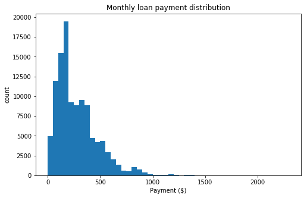

```python
binsize = 50
bins = np.arange(0, df_loans['MonthlyLoanPayment'].max()+binsize, binsize)

plt.figure(figsize=[8, 5])
plt.hist(data = df_loans, x = 'MonthlyLoanPayment', bins = bins)
plt.xlabel('Payment ($)')
plt.ylabel('count')
plt.title('Monthly loan payment distribution')
plt.show()
```

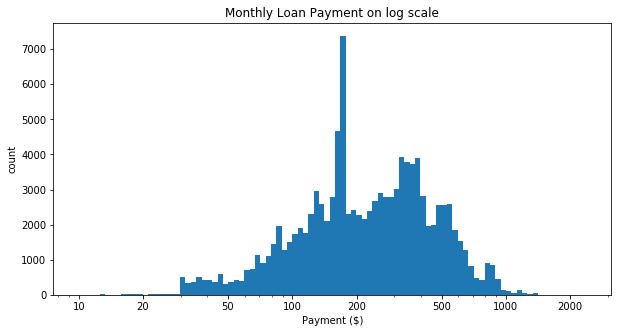

```python
# Zooming in using a log scale
log_binsize = 0.025
bins = 10 ** np.arange(1, np.log10(df_loans['MonthlyLoanPayment'].max())+log_binsize, log_binsize)

plt.figure(figsize=[10, 5])
plt.hist(data = df_loans, x = 'MonthlyLoanPayment', bins = bins)
plt.xscale('log')
plt.xticks([10, 20, 50, 100, 200, 500, 1e3, 2e3], ['10', '20','50', '100', '200', '500', '1000', '2000'])
plt.xlabel('Payment ($)')
plt.ylabel('count')
plt.title('Monthly Loan Payment on log scale')
plt.show()
```

##### Observation

The visualization above shows a normal distribution with the peak between 100 and 200 and some increase at the 500.

### Discuss the distribution(s) of your variable(s) of interest. Were there any unusual points? Did you need to perform any transformations?

> Homeowners are more commonly found requesting loans on the platform than their counterparts. The majority of borrowers on the platform have verifiable means of income. Requesting a loan without a verifiable source of income may not yeild the most desired results. An interesting pattern observed is that the loan amount has been increasing from 2009 until 2013 where it was at its highest. Year 2013 had the highest loan creation. California (CA) had the biggest number of loans.

## Bivariate Exploration

> Next I will find interesting relationships that show the influence of one variable on the other,including our variables of interest Borrower APR and Prosper score.

**What notable correlation can we see from the numeric and categorical variables of the dataset?**

```python
df_loans.info()
```

```
<class 'pandas.core.frame.DataFrame'>
Int64Index: 111682 entries, 0 to 113936
Data columns (total 25 columns):
ListingCreationDate          111682 non-null object
CreditGrade                  26698 non-null object
Term                         111682 non-null int64
LoanStatus                   111682 non-null object
ClosedDate                   52834 non-null object
BorrowerAPR                  111682 non-null float64
BorrowerRate                 111682 non-null float64
LenderYield                  111682 non-null float64
ProsperRating (Alpha)        84853 non-null category
ProsperScore                 84853 non-null float64
ListingCategory (numeric)    111682 non-null int64
BorrowerState                107554 non-null object
Occupation                   110349 non-null object
EmploymentStatus             111682 non-null object
AmountDelinquent             106315 non-null float64
IncomeRange                  105390 non-null category
StatedMonthlyIncome          111682 non-null float64
LoanCurrentDaysDelinquent    111682 non-null int64
LoanOriginalAmount           111682 non-null int64
LoanOriginationDate          111682 non-null datetime64[ns]
MonthlyLoanPayment           111682 non-null float64
LP_ServiceFees               111682 non-null float64
Investors                    111682 non-null int64
IncomeVerifiable             111682 non-null bool
IsBorrowerHomeowner          111682 non-null bool
dtypes: bool(2), category(2), datetime64[ns](1), float64(8), int64(5), object(7)
memory usage: 24.2+ MB
```

#### Correlation Matrix

```python
#Identify Numeric and Catergorical Variables
numeric = ['Term', 'BorrowerAPR', 'BorrowerRate', 'LenderYield', 'ProsperScore',
                     'StatedMonthlyIncome', 'LoanOriginalAmount', 'MonthlyLoanPayment', 'LP_ServiceFees', 'Investors',
                    'AmountDelinquent','LoanCurrentDaysDelinquent']
categorical = [ 'ProsperRating (Alpha)', 'BorrowerState', 'EmploymentStatus', 'IncomeRange','IsBorrowerHomeowner','IncomeVerifiable']
```

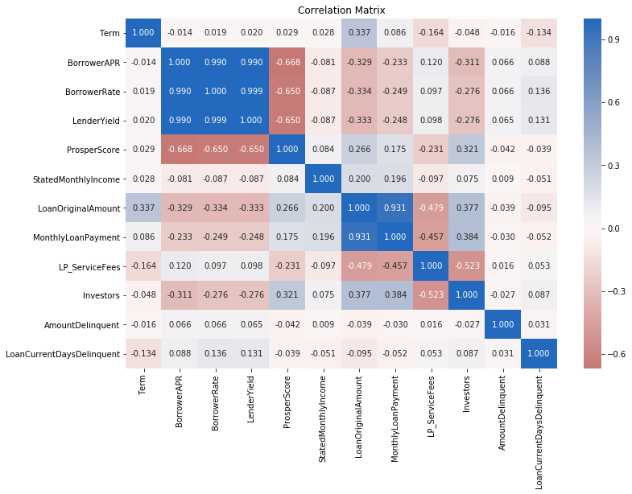

```python
# Correlation matrix for all numeric variables
plt.figure(figsize = [12, 8])
sb.heatmap(df_loans[numeric].corr(), annot = True, fmt = '.3f',
           cmap = 'vlag_r', center = 0)
plt.title('Correlation Matrix')
plt.show()
```

#### Plot Matrix

```python
#Identify Numeric and Catergorical Variables
numeric_var = ['BorrowerAPR', 'BorrowerRate', 'LenderYield', 'ProsperScore',
                     'StatedMonthlyIncome', 'LoanOriginalAmount', 'MonthlyLoanPayment']
categorical_var = [ 'ProsperRating (Alpha)', 'BorrowerState', 'EmploymentStatus', 'IncomeRange','IsBorrowerHomeowner','IncomeVerifiable']
```

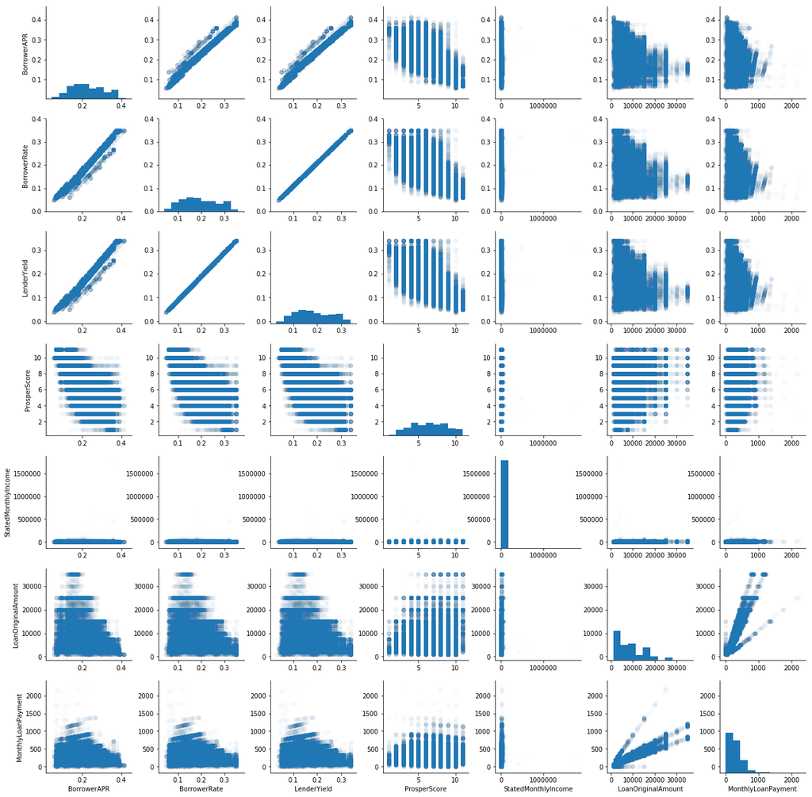

```python
# plot matrix

fig = sb.PairGrid(df_loans[numeric_var].dropna())
fig.map_diag(plt.hist, color = base_color)
fig.map_offdiag(plt.scatter,color = base_color, alpha=0.01);
```

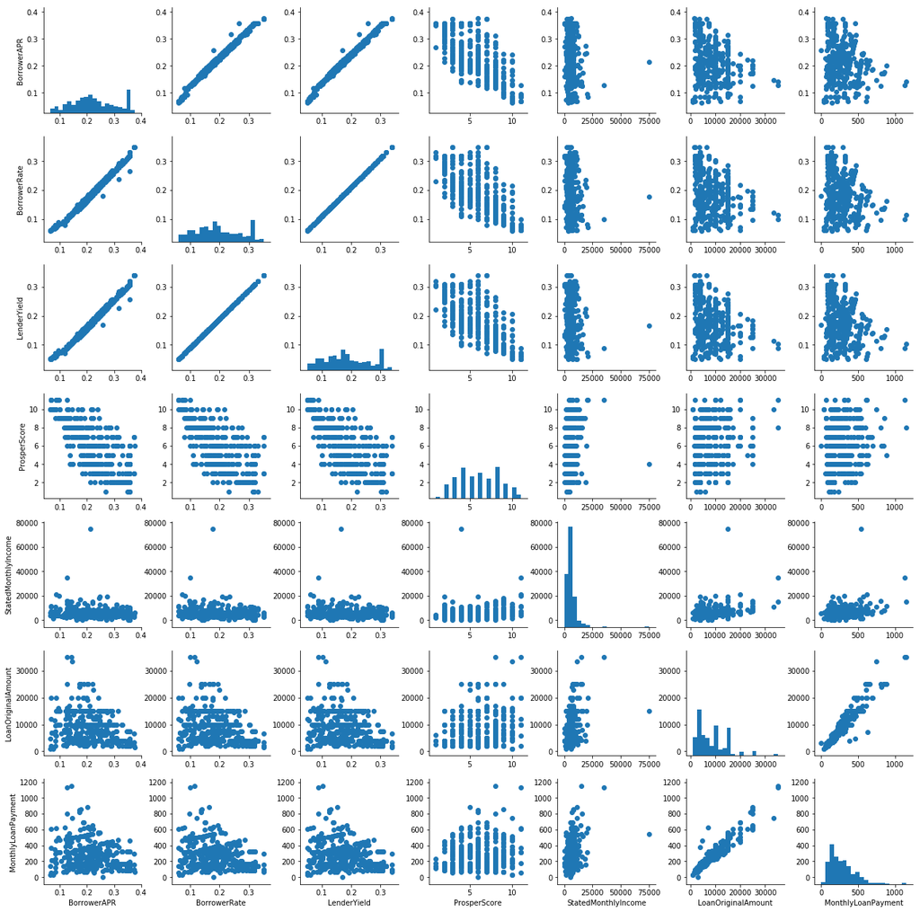

```python
# Second Plotmatrix (Clearer)
df_loans_samp = df_loans.sample(n=500, replace = False)

g = sb.PairGrid(data = df_loans_samp[numeric_var].dropna())
g = g.map_diag(plt.hist, bins = 20);
g.map_offdiag(plt.scatter);
```

##### Observation

There is a Negative correlation between prosper score & APR, and prosper score & Lender yield. Also there is a Negative correlation between prosper ratings & APR, and prosper score & Lender yield.

**Loan Original Amount VS Borrower APR**

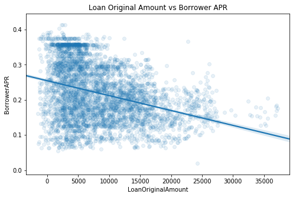

```python
#4000 entries will be sampled from the dataset
plt.figure(figsize=(8, 5))
sb.regplot(data=df_loans.sample(4000, random_state=1), x='LoanOriginalAmount', y='BorrowerAPR',
            x_jitter=2500, color = base_color, scatter_kws={'alpha': 0.1});
plt.title('Loan Original Amount vs Borrower APR');
```

##### Observation

Higher loan amounts are more likely to come with lower interest rates than smaller alternatives.

**Loan Original Amount vs Loan Term**

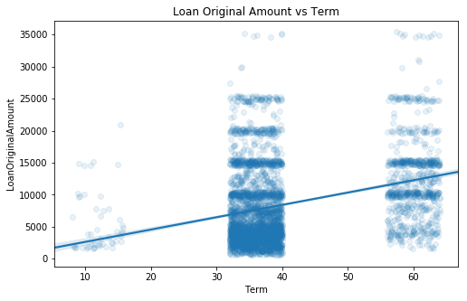

```python
#4000 entries will be sampled from the dataset
plt.figure(figsize=(8, 5))
sb.regplot(data=df_loans.sample(4000, random_state=1), x='Term', y='LoanOriginalAmount',
            x_jitter=4, color= base_color, y_jitter=500,scatter_kws={'alpha': 0.1});
plt.title('Loan Original Amount vs Term');
```

##### Observation

From the visualization we can see that the loan original amount clearly increases with loan term.

**Borrower APR Vs Status of Loan**

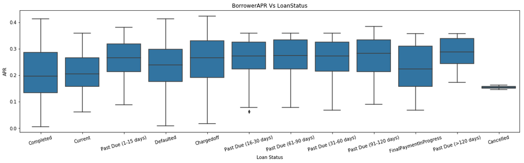

```python
# Borrower APR vs Status of Loan
plt.figure(figsize = [20, 5])
sb.boxplot(data=df_loans,y='BorrowerAPR',x='LoanStatus',color=base_color);
plt.title('BorrowerAPR Vs LoanStatus');
plt.ylabel('APR');
plt.xlabel('Loan Status');
plt.xticks(rotation=15);
```

##### Observation

We notice that Current and completed loans have lower rate than the past-due loans which means past due loans attracts more APR.

### Talk about some of the relationships you observed in this part of the investigation. How did the feature(s) of interest vary with other features in the dataset?

> Another interesting pattern Original pattern is that the loan amount has been increasing from 2009 until 2013 where it was at its highest.

## Multivariate Exploration

> Finally I will explore how the borrower APR relates to other variables (multiple).

**What is the relationship between the Lener Yield, Borrower APR and Prosper Score?**

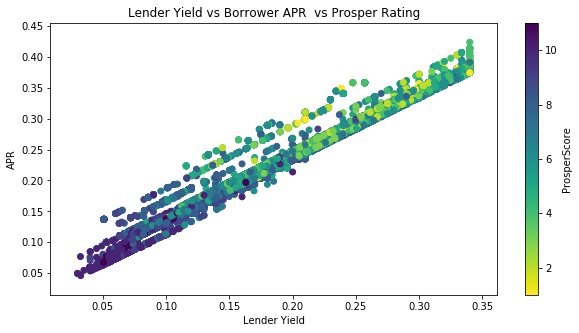

```python
plt.figure(figsize = [10, 5])
plt.scatter(data=df_loans,x='LenderYield',y = 'BorrowerAPR',c='ProsperScore',cmap = 'viridis_r')
plt.colorbar(label = 'ProsperScore');
plt.title('Lender Yield vs Borrower APR  vs Prosper Rating');
plt.xlabel('Lender Yield');
plt.ylabel('APR');
```

##### Observation

Borrower APR and Lender yield are directly positively correlated as when the interest borrowers pays more , the lender yield will increase. Higher the prosper score will lower Borrower APR and then the lender yield will also be lower.

**What is the relationship between the Loan Status, Borrower APR and Employment status?**

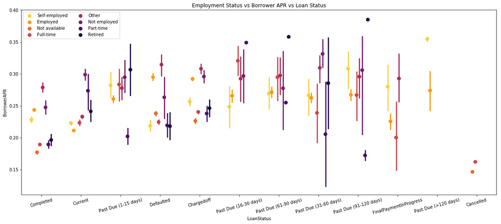

```python
# EmploymentStatus vs BorrowerAPR in each LoanStatus
fig = plt.figure(figsize = [20,8])
ax = sb.pointplot(data = df_loans, x = 'LoanStatus', y = 'BorrowerAPR', hue = 'EmploymentStatus', linestyles = "",
                  dodge = 0.5, palette = 'inferno_r')
plt.title('Employment Status vs Borrower APR vs Loan Status')
plt.ylabel('BorrowerAPR')
plt.xticks(rotation=15)
plt.legend(ncol=2)
plt.show();
```

**What is the relationship between BorrowerAPR, LoanOriginalAmount, and ProsperRating?**

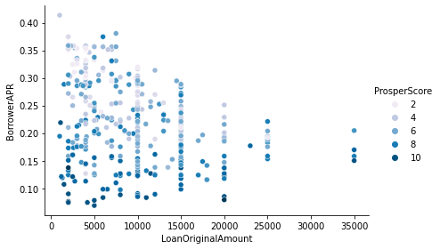

```python
sb.relplot(data=df_loans.sample(500, random_state=1), y='BorrowerAPR', x='LoanOriginalAmount',
            hue='ProsperScore', palette='PuBu', height=4, aspect=1.5);
```

##### Observation

Borrowers with low prosper ratings take smaller loans at higher percentage rates, while those with higher prosper ratings enjoy higher loan amounts at lower rates.

**What is the relationship between BorrowerAPR, LoanOriginalAmount, and IncomeRange?**

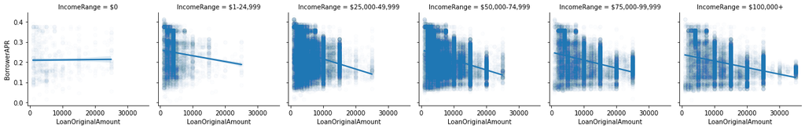

```python
fig = sb.FacetGrid(data=df_loans, col='IncomeRange')
fig.map(sb.regplot, 'LoanOriginalAmount', 'BorrowerAPR', color= base_color, scatter_kws={'alpha': 0.01});
```

### Talk about some of the relationships you observed in this part of the investigation. Were there features that strengthened each other in terms of looking at your feature(s) of interest?

> Past due loans have high interests. The high income earners enjoy larger loans at lower APRs than the low income earners. Borrowers with low prosper ratings take smaller loans at higher percentage rates.

## Conclusions

> This exploration of Prosper loan data was aimed at identifying what affects Borrower APR: The results show that
> - The high income earners enjoy larger loans at lower APRs than the low income earners.
> - Borrowers with low prosper ratings take smaller loans at higher APRs.
> - Borrower APR and Lender yield are directly positively correlated as when the interest borrowers pays more.
> - Higher loan amounts are more likely to come with lower APRs when compared to small loan amounts.